# MapComp: Merluccius merluccius

# Introduction to the MapCompR Package

The MapCompR package is a valuable tool for comparing and validating marine ecosystem models (MEMs) maps against real observations, such as those obtained from oceanographic campaigns. Therefore, this package is used to assess the accuracy of MEMs by comparing their biomass predictions to observed data, enabling scientists to evaluate simulation quality and refine models accordingly.

The primary objective of MapCompR is to provide a set of functions that facilitate the comparison and validation of marine ecosystem model outputs with real data, which is crucial for enhancing our understanding of marine processes and making informed decisions in marine resource management.

# Install package

Before using the MapCompR package, it is necessary to install it. This can be accomplished by using the devtools::install_github() function to download the package from its GitHub repository.

```r
devtools::install_github("jazelouled/MapCompR_FishMIP")
library(MapCompR)
```

# Load observed and predicted data

To effectively utilize the MapCompR package, it is essential to have access to at least two key components: the predicted values from a model and the corresponding observed values of that model. In the following code snippet, observed abundance and biomass data for the species *Merluccius merluccius* are loaded from a CSV file, and predicted data is loaded from raster files (it is important that the rasters are in **.asc**)-

```r
# Load your observed data
observed_data <- read.csv("./data/Abundancia_biomasa_GSA1_2_6.csv", sep = ";")
observed_data_ <- observed_data[observed_data$ESPECIE %like% "Merluccius merluccius",]

# Modify your observed data
observed_data_$longitud <- rowMeans(observed_data_[, c("LONGITUD_INI", "LONGITUD_VIR")])
observed_data_$latitud <- rowMeans(observed_data_[, c("X.LATITUD_INI", "LATITUD_VIR")])
```

```r
# Load predict data
Ecospace_data <- dir("./Ecospace_data/", pattern = "Adult hake", full.names = T)
Ecospace_data <- Ecospace_data[Ecospace_data %like% "Biomass"]
```

```r
# Environmental variable
bathy <- raster("./GEBCO_2014_2D.nc")
```

# ObsPredBiomassDF

The obsPredBiomassDF function is used to create a data frame containing both observed and predicted biomass data. In this step, you can also specify the raster variable used for prediction and define an extraction buffer:

```r
hh <- MapCompR::obsPredBiomassDF(observed = observed_data_, # observed data
                       observedLon = "longitud", # NAME column longitude
                       observedLat = "latitud", # NAME column latitude
                       observedBiomass = "BIOMASA", # NAME column observed data
                       predicted = Ecospace_data, # RASTER (.asc) prediction
                       rasterVariable = bathy, # variable
                       bufferExtract = 20
                       )
```

# Visual_inspection

The function visual_inspection function allows for visual analysis of the comparison between observed and predicted biomass data. You can specify the columns containing observed and predicted data, as well as the year and raster variable:

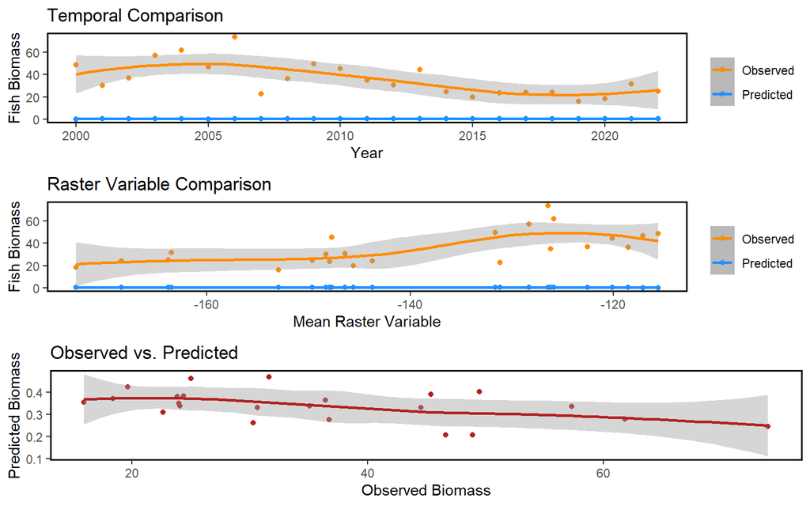

```r
visual_inspection(df = hh,
                  observed = "biomass_observed",
                  predicted = "biomass_predicted",
                  year = "year",
                  rasterVariable = "variable")
```

# Calculate_metrics

```r
calculate_metrics(df = hh,
                  observed = "biomass_observed",
                  predicted = "biomass_predicted"
                  )
```

```
## $metrics
##        bias     rmse        mef       nmae     mae
## 1 -34.84486 63.87664 -0.4239617 0.03644733 34.8509
##
## $plots
```

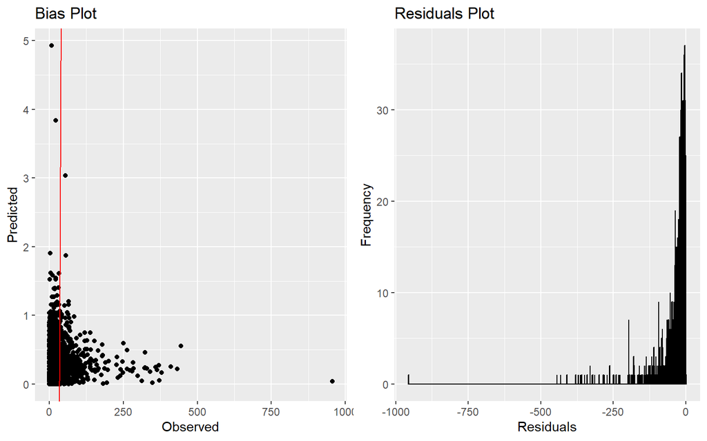

# TaylorD

The taylorD function calculates the Taylor similarity index between observed and predicted biomass data. The taylor Diagram is based on the standard deviation, the correlation and also de RMSE:

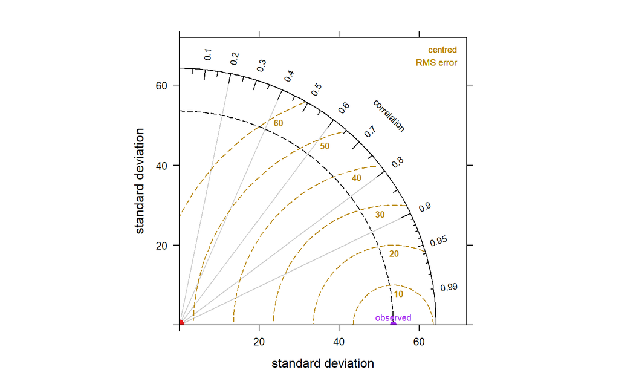

```r
taylorD(observed = hh$biomass_observed,
        predicted = hh$biomass_predicted)
```